# Возможности R для работы с пространственными данными

Мастер-класс на IV Конференции сообщества природоохранных ГИС в России Национальный парк «Валдайский», 05 октября 2019 г.

Никита Платонов (ИПЭЭ РАН)

Обновлено: 2019-09-28 23:55

Abstract

Для желающих сделать первые шаги в освоении R демонстрация основ работы с интерфейсом командной строки в R, позволяющей создавать скрипты и получать воспроизводимые результаты. Узнаете, как пространственные векторные и растровые данные могут попасть в R и как они выглядят в R. Попробуете сделать обработку, анализ и визуализацию пространственных данных.

# Планирование (до 27 сентября)

## Предлагаемый подход к формированию темы мастер-класса

Планируется, что основные материалы для проведения мастер-класса появятся здесь к 27 сентября. Предполагается, что некоторые дополнения могут быть внесены и в более поздний срок, но с учетом того, чтобы эти изменения не потребовали существенного заимствования времени от занятия. Основной режим проведения мастер-класса - это копирование/вставка фрагмента кода, поэтому этот материал может быть использован дистанционными участниками.

Факультативно задумывается и осваивается вариант занятия с использованием Jupyter R Notebook. Установку необходимых программных компонентов нужно выполнить самостоятельно.

Пожелания по затрагиванию какой-либо темы могут быть приняты ✉ не позднее 27 сентября.

# Подготовка (до 05 октября)

## Операционные системы пользователя

Не для всех операционных систем есть скомпилированные модули (ядро R, библиотеки). В таком случае модули компилируются, и на это уходит какое-то время. Поэтому если ОС не OS Windows, то этот этап нужно пройти заранее.

## Установка базового R

Установить или обновить R, например, [отсюда](https://cran.rstudio.com/). Актуальная версия 3.6.1. Не ниже версии 3.0.

## Установка необходимых библиотек

```r
pkgList <- c("rgdal","sf","raster","ggplot2","leaflet","mapview","mapedit"
            ,"knitr","rmarkdown","jpeg","png","ursa")
whoisready <- sapply(pkgList,function(pkg) {
   if (pkg=="ursa") {
      v <- try(packageVersion("ursa"))
      if ((inherits(v,"try-error"))||(v<"3.8.15"))
         install.packages("ursa", repos="http://R-Forge.R-project.org")
   }
   if (requireNamespace(pkg))
      return(TRUE)
   install.packages(pkg,repos="https://cloud.r-project.org/")
   requireNamespace(pkg)
})
whoisready
```

```
##     rgdal        sf    raster   ggplot2   leaflet   mapview   mapedit     knitr
##      TRUE      TRUE      TRUE      TRUE      TRUE      TRUE      TRUE      TRUE
## rmarkdown      jpeg       png      ursa
##      TRUE      TRUE      TRUE      TRUE
```

Если отображается `TRUE` для всех библиотек, то подготовка к занятию осуществлена успешно.

```r
c('Everything is ready?'=all(whoisready))
```

```
## Everything is ready?
##                 TRUE
```

Если где-то выскочило `FALSE` (например, для библиотеки “foo”), то можно попробовать его установить заново функцией `install.packages("foo")`.

## Установка дополнительного программного обеспечения

### Pandoc

Pandoc необходим для создания воспроизводимого результата. Этот шаг опциональный, и может быть пропущен, но в этом случае на занятии будет пропущен раздел по публикации результатов.

[Ссылка](https://pandoc.org/installing.html) на страницу для скачивания. Для пользователей Windows достаточно перейти к [скачиванию актуального релиза](https://github.com/jgm/pandoc/releases/latest), и выбрать либо установщик (`*.msi`), либо архив (`*.zip`). Запомнить путь, куда произведена установка и где находится файл `pandoc.exe` и добавить этот путь в переменную окружения `%PATH%`, например: WindowsKey+Q, ввести “Переменные среды/Environment Variables”, попасть в окошко “Свойства Системы/System Properties”, нажать на кнопку “Переменные среды/Environment Variables” и отредактировать пользовательскую или системную переменную PATH, добавив путь к `pandoc.exe`.

Чтобы проверить правильно ли установлен Pandoc, в новой R-сессии:

```r
rmarkdown::pandoc_available()
```

```
## [1] TRUE
```

### Jupyter R Notebook

Jupyter Notebook для работы с кодом в браузере.

1. [Загрузить](https://docs.conda.io/en/latest/miniconda.html) и установить менеджер Miniconda (проверено на Windows 64bit Python 3.7).
2. Запустить `conda` (На Windows попробовать WinKey+Q и начать вводить “Anaconda”)
3. Последовательно выполнить команды (в среде Conda, не в среде R):

| Команда | Описание |
| --- | --- |
| `conda install jupyter` | установка Jupyter Notebook |
| `conda install -c r r-recommended r-irkernel` | Установка R, базовых библиотек и библиотеки для использования R в Jupyter Notebook |
| `conda install -c conda-forge jupytext` | Установка преобразователя кода R в формат Jupyter Notebook |

Предварительно скачайте `main.R` или только код `codeOnly.R`, если будете использовать на занятии Jupyter Notebook. Если будет проблема с кодировкой, возьмите `codeOnly1251.R` Предупреждение: описательный текст (markdown) местами не отформатирован, в частности, не будут отображаться таблицы; также не будут отображаться html-виджеты.

## Как использовать материал

Предполагается, что во время занятий будет использоваться интерактивный режим: либо простая среда R (R, запущенный без команд), либо графическая среда R GUI, либо RStudio.

Блок исходного кода выделен моноширинным шрифтом с подсветкой синтаксиса, после которого либо приведен текстовый вывод (более бледный цвет шрифта), либо графический вывод (рисунок, таблица). В среде R нужно вводить код из верхнего блока и сравнивать полученный вывод с содержимым нижнего блока.

К примеру, ниже приведен пример вывода числа *π*: сверху – команда, снизу – выход.

```r
pi
```

```
## [1] 3.141593
```

## Начало работы

Текущий путь, где мы находимся. Здесь появятся файлы, созданные в процессе занятия.

```r
getwd()
```

```
## [1] "D:/RAS/2019/SCGIS"
```

Его можно поменять через меню RGui/RStudio или с помощью `setwd()`.

Зафиксируем генератор псевдослучайных чисел на определенную последовательность

```r
set.seed(353)
sample(10)
```

```
##  [1]  2  7 10  6  4  1  3  9  5  8
```

Команда для проверки кириллицы:

```r
print(c('Здесь кириллица?'="Да!"),quote=FALSE)
```

```
## Здесь кириллица?
##              Да!
```

Если вывод не читаемый, то возможные пути решения:

1. Задать кириллицу для символьной локали:

```r
if (.Platform$OS.type=="windows")
   Sys.setlocale("LC_CTYPE","Russian")
```

2. Если скрипты подключаются через `source()`, то можно настроить запуск R через конфигурационные файлы. Например, скачать .Rprofile, разместить в рабочей директории, перегрузить R. Файл имеет следующую структуру:

```
local({
   options(encoding="UTF-8")
   Sys.setlocale("LC_CTYPE","Russian")
 })
```

3. Если скрипт `bar.R` с кириллицей в кодировке UTF-8 запускается из командной строки, то использовать следующие параметры запуска.

```
 R --encoding UTF-8 -f bar.R
```

# Занятие (05 октября)

## R как ГИС?

- R устроен так, что можно реализовать сложные структуры данных, со средствами их инспектирования, что вполне применимо для пространственных данных и их метаданных
- В R есть инструменты для анализа данных
- В R есть инструменты для визуализации
- *Как особенность развития до текущего момента*: воспроизводимость реализована лучше интерактивности
- В R уже многое сделано по манипуляции с пространственными данными: пользователю не обязательно быть разработчиком

## Структуры данных

### Числа и имена значений

```r
(a1 <- seq(7))
```

```
## [1] 1 2 3 4 5 6 7
```

```r
str(a1)
```

```
##  int [1:7] 1 2 3 4 5 6 7
```

```r
a2 <- a1
names(a2) <- format(Sys.Date()+a1-1,"%A")
a2
```

```
##  Saturday    Sunday    Monday   Tuesday Wednesday  Thursday    Friday
##         1         2         3         4         5         6         7
```

```r
str(a2)
```

```
##  Named int [1:7] 1 2 3 4 5 6 7
##  - attr(*, "names")= chr [1:7] "Saturday" "Sunday" "Monday" "Tuesday" ...
```

### Целые числа, числа с плавающей точкой

```r
str(a2+0L)
```

```
##  Named int [1:7] 1 2 3 4 5 6 7
##  - attr(*, "names")= chr [1:7] "Saturday" "Sunday" "Monday" "Tuesday" ...
```

```r
str(a2+0)
```

```
##  Named num [1:7] 1 2 3 4 5 6 7
##  - attr(*, "names")= chr [1:7] "Saturday" "Sunday" "Monday" "Tuesday" ...
```

```r
typeof(a2+0L)
```

```
## [1] "integer"
```

```r
typeof(a2+0)
```

```
## [1] "double"
```

### Логические значения, строки

```r
(a3 <- sample(c(TRUE,FALSE),length(a2),replace=TRUE))
```

```
## [1] FALSE FALSE  TRUE  TRUE  TRUE FALSE  TRUE
```

```r
class(a3)
```

```
## [1] "logical"
```

```r
str(a3)
```

```
##  logi [1:7] FALSE FALSE TRUE TRUE TRUE FALSE ...
```

```r
(a4 <- names(a2))
```

```
## [1] "Saturday"  "Sunday"    "Monday"    "Tuesday"   "Wednesday" "Thursday"
## [7] "Friday"
```

```r
class(a4)
```

```
## [1] "character"
```

```r
str(a4)
```

```
##  chr [1:7] "Saturday" "Sunday" "Monday" "Tuesday" "Wednesday" "Thursday" ...
```

### Списки одинаковой длины

```r
(a5 <- list(num=a1[c(1,3:7)],char=a4[-2]))
```

```
## $num
## [1] 1 3 4 5 6 7
##
## $char
## [1] "Saturday"  "Monday"    "Tuesday"   "Wednesday" "Thursday"  "Friday"
```

```r
str(a5)
```

```
## List of 2
##  $ num : int [1:6] 1 3 4 5 6 7
##  $ char: chr [1:6] "Saturday" "Monday" "Tuesday" "Wednesday" ...
```

```r
class(a5)
```

```
## [1] "list"
```

```r
length(a5)
```

```
## [1] 2
```

```r
sapply(a5,length)
```

```
##  num char
##    6    6
```

### Таблицы

```r
(a6 <- data.frame(num=a1[c(1,3:7)],char=a4[-2]))
```

```
##   num      char
## 1   1  Saturday
## 2   3    Monday
## 3   4   Tuesday
## 4   5 Wednesday
## 5   6  Thursday
## 6   7    Friday
```

```r
str(a6)
```

```
## 'data.frame':    6 obs. of  2 variables:
##  $ num : int  1 3 4 5 6 7
##  $ char: chr  "Saturday" "Monday" "Tuesday" "Wednesday" ...
```

```r
class(a6)
```

```
## [1] "data.frame"
```

```r
dim(a6)
```

```
## [1] 6 2
```

### Списки различной длины

```r
(a7 <- list(x=sample(a1,3),y=sample(a1,5)))
```

```
## $x
## [1] 7 3 2
##
## $y
## [1] 4 7 6 5 1
```

```r
str(a7)
```

```
## List of 2
##  $ x: int [1:3] 7 3 2
##  $ y: int [1:5] 4 7 6 5 1
```

```r
class(a7)
```

```
## [1] "list"
```

```r
length(a7)
```

```
## [1] 2
```

```r
sapply(a7,length)
```

```
## x y
## 3 5
```

### Матрицы

```r
(a11 <- matrix(sample(seq(24)),ncol=4,nrow=3))
```

```
##      [,1] [,2] [,3] [,4]
## [1,]    6   23   11   20
## [2,]    2   10   13   21
## [3,]    8    1    4    3
```

Размерность массива

```r
dim(a11)
```

```
## [1] 3 4
```

Структура данных массива

```r
str(a11)
```

```
##  int [1:3, 1:4] 6 2 8 23 10 1 11 13 4 20 ...
```

### Массивы

```r
(a8 <- array(sample(24),dim=c(3,4,2)))
```

```
## , , 1
##
##      [,1] [,2] [,3] [,4]
## [1,]   15   21    3   16
## [2,]   14   11   23   10
## [3,]   18   24    6   22
##
## , , 2
##
##      [,1] [,2] [,3] [,4]
## [1,]   19    9    4   20
## [2,]    1   13   17    5
## [3,]    2    8    7   12
```

```r
str(a8)
```

```
##  int [1:3, 1:4, 1:2] 15 14 18 21 11 24 3 23 6 16 ...
```

```r
class(a8)
```

```
## [1] "array"
```

### Факторы

```r
(a9 <- factor(sample(a4),levels=a4))
```

```
## [1] Monday    Friday    Wednesday Sunday    Tuesday   Thursday  Saturday
## Levels: Saturday Sunday Monday Tuesday Wednesday Thursday Friday
```

```r
str(a9)
```

```
##  Factor w/ 7 levels "Saturday","Sunday",..: 3 7 5 2 4 6 1
```

```r
class(a9)
```

```
## [1] "factor"
```

```r
(a10 <- factor(sample(a4),levels=a4,ordered=TRUE))
```

```
## [1] Tuesday   Saturday  Thursday  Sunday    Monday    Wednesday Friday
## 7 Levels: Saturday < Sunday < Monday < Tuesday < Wednesday < ... < Friday
```

```r
str(a10)
```

```
##  Ord.factor w/ 7 levels "Saturday"<"Sunday"<..: 4 1 6 2 3 5 7
```

```r
class(a10)
```

```
## [1] "ordered" "factor"
```

## Визуализация данных

Базовые средства R для визуализации (библиотека `graphics`) пространственных данных:

- `points()` – отображение точек (геометрия POINT)
- `lines()`, `segments()`, `contour()` – отображение линий (геометрия LINESTRING)
- `polygon()`, `polypath()` – отображение полигонов (геометрия POLYGON)
- `image()`, `rasterImage()` – растровые изображения
- `text()`, `legend()` – аннотациии
- `axis()`, `mtext()` – рамочное оформление

### Пример путешествия мимо/через Спб

```r
n <- 60
seqx <- seq(20,40,by=5)
seqy <- seq(55,65,by=2)
x <- sort(runif(n,min=min(seqx),max=max(seqx)))
y <- sort(runif(n,min=min(seqy),max=max(seqy)))
```

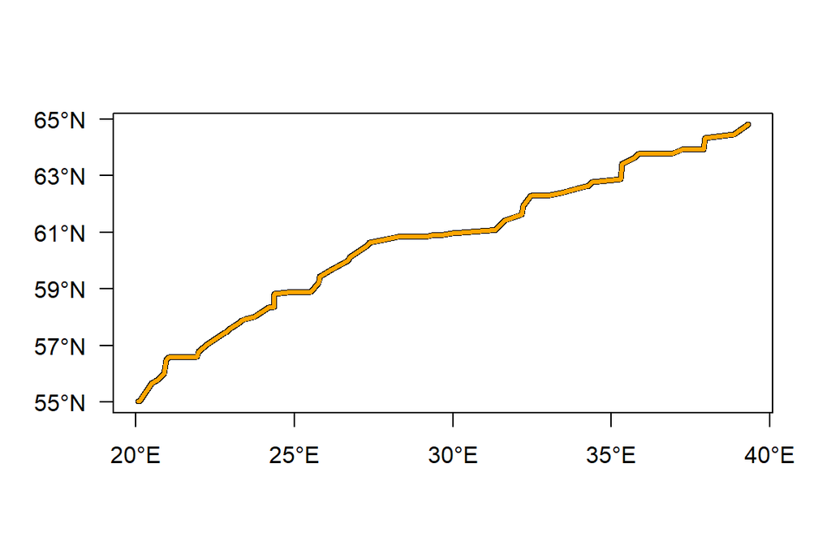

```r
plot(x,y,type="n",asp=NA,axes=FALSE,xlab="",ylab="")
lines(x,y,lwd=4,col="black")
lines(x,y,lwd=3,col="orange")
box()
axis(1,at=seqx,lab=paste0(seqx,"°E"),lwd=0,lwd.ticks=1,las=1)
axis(2,at=seqy,lab=paste0(seqy,"°N"),lwd=0,lwd.ticks=1,las=1)
```

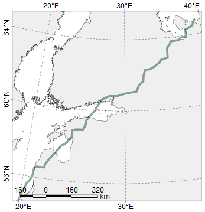

```r
e <- sf::st_sfc(sf::st_linestring(cbind(x,y)),crs=4326)
ursa::session_grid(NULL)
ursa::glance(e,blank="white",coast.fill="#00000010",height=320,dpi=66
            ,col="black",plot.lwd=5)
```

### `data(volcano)`

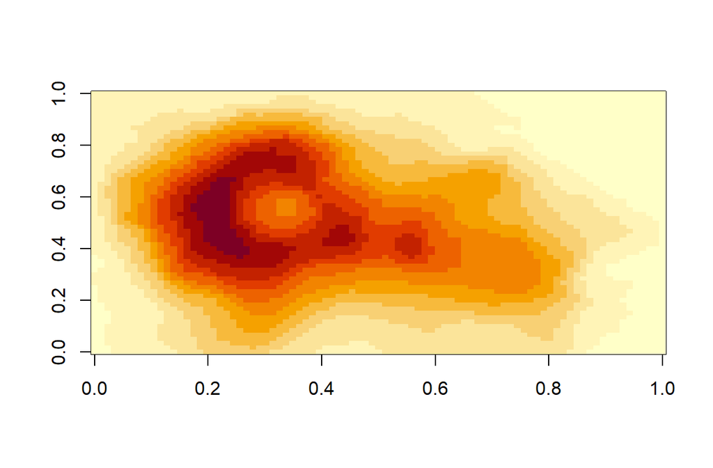

```r
image(volcano)
```

Это вулкан Maunga Whau (Mt Eden).

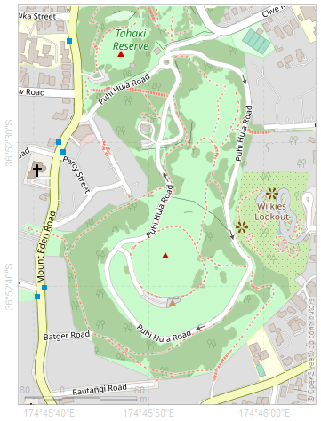

```r
try(ursa::glance("Mount Eden",place="park",dpi=83))
```

## Манипуляции с файлами пространственных данных

Векторные данные

| Библиотека | Формат | Импорт | Экспорт |
| --- | --- | --- | --- |
| `sp` | [GDAL vector drivers](https://gdal.org/drivers/vector/index.html) | **`rgdal`**`::readOGR()` | **`rgdal`**`::writeOGR()` |
| [`sf`](https://r-spatial.github.io/sf/) | [GDAL vector drivers](https://gdal.org/drivers/vector/index.html) | `st_read()` | `st_write()` |

Растровые данные

| Библиотека | Формат | Импорт | Экспорт |
| --- | --- | --- | --- |
| `sp` | [GDAL raster drivers](https://gdal.org/drivers/raster/index.html) | **`rgdal`**`::readGDAL()` | **`rgdal`**`::writeGDAL()` |
| `raster` | [GDAL raster drivers](https://gdal.org/drivers/raster/index.html) | `raster()`, `brick()`, `stack()` | `writeRaster()` |
| [`ncdf4`](https://cran.rstudio.com/web/packages/ncdf4/) | [NetCDF](https://gdal.org/drivers/raster/netcdf.html) | `nc_open()` | `nc_create()` |
| `ursa` | [ENVI](https://gdal.org/drivers/raster/envi.html) | `read_envi()` | `write_envi()` |

## Особенности форматов данных

### Растровые данные

- Для хранения многослойные растров используется BSQ/BIL/BIP чередование слоев/строк/пикелей. Самый неэффективный - это BIP. При пространственно-временном анализе можно выбрать BIL, для большинства случаев - BSQ.
- Целочисленный GeoTIFF быстро пишется и читается при использовании функций из библиотеки `rgdal`

### Векторные данные

- Хорошую скорость чтения и записи демонстрирует формат “SQLite” при использовании библиотеки `sf`.
- “GeoJSON” не очень быстрый.
- При записи использовать опции, предусмотренные для выбранного формата данных
- При записи “ESRI Shapefile” обращать внимания на *.prj, так как у QGIS и ESRI-продуктов разные восприятия файлов проекций.

## Импорт пространственных данных

### Используемые данные для примера

```r
(shpname <- system.file("vectors","scot_BNG.shp",package="rgdal"))
```

```
## [1] "C:/Software/Rtools/library/rgdal/vectors/scot_BNG.shp"
```

```r
file.exists(shpname)
```

```
## [1] TRUE
```

```r
(tifname <- system.file("pictures/cea.tif",package="rgdal"))
```

```
## [1] "C:/Software/Rtools/library/rgdal/pictures/cea.tif"
```

```r
file.exists(tifname)
```

```
## [1] TRUE
```

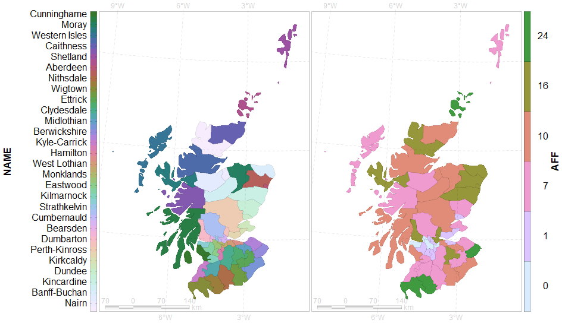

```r
ursa::session_grid(NULL)
ursa::glance(shpname,coast=FALSE,field="(NAME|AFF)",blank="white"
            ,legend=list("left","right"),dpi=88)
```

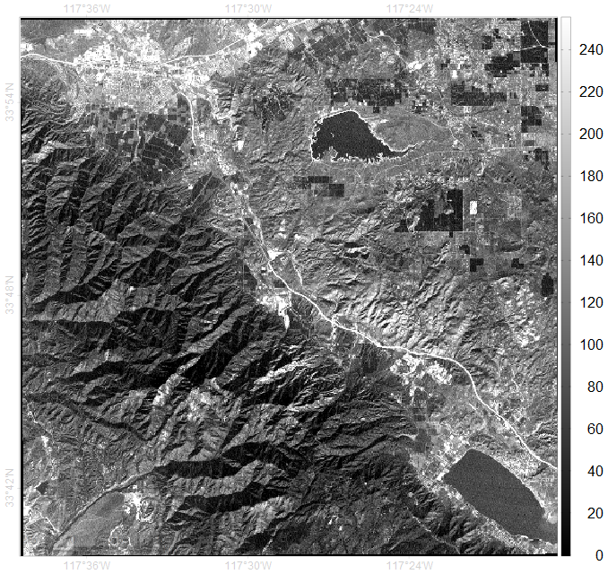

```r
ursa::session_grid(NULL)
ursa::glance(tifname,coast=FALSE,pal.from=0,pal=c("black","white"),dpi=96)
```

### Векторные данные – `rgdal/sp`

```r
rgdal::ogrInfo(shpname)
```

```
## Driver: ESRI Shapefile; number of rows: 56
## Feature type: wkbPolygon with 2 dimensions
## Extent: (7094.552 529495) - (468285.5 1218342)
## CRS: +proj=tmerc +lat_0=49 +lon_0=-2 +k=0.9996012717 +x_0=400000 +y_0=-100000 +datum=OSGB36 +units=m +no_defs
## LDID: 0
## Number of fields: 13
##      name type length typeName
## 1   SP_ID    4      5   String
## 2    NAME    4     13   String
## 3    ID_x    2     19     Real
## 4   COUNT    2     19     Real
## 5     SMR    2     19     Real
## 6    LONG    2     19     Real
## 7     LAT    2     19     Real
## 8      PY    2     19     Real
## 9    EXP_    2     19     Real
## 10    AFF    2     19     Real
## 11 X_COOR    2     19     Real
## 12 Y_COOR    2     19     Real
## 13   ID_y    2     19     Real
```

```r
b.sp <- rgdal::readOGR(shpname)
str(head(b.sp,2))
```

```
## Formal class 'SpatialPolygonsDataFrame' [package "sp"] with 5 slots
##   ..@ data       :'data.frame':  2 obs. of  13 variables:
##   .. ..$ SP_ID : chr [1:2] "0" "1"
##   .. ..$ NAME  : chr [1:2] "Sutherland" "Nairn"
##   .. ..$ ID_x  : num [1:2] 12 13
##   .. ..$ COUNT : num [1:2] 5 3
##   .. ..$ SMR   : num [1:2] 279 278
##   .. ..$ LONG  : num [1:2] 58.1 57.5
##   .. ..$ LAT   : num [1:2] 4.64 3.98
##   .. ..$ PY    : num [1:2] 37521 29374
##   .. ..$ EXP_  : num [1:2] 1.8 1.1
##   .. ..$ AFF   : num [1:2] 16 10
##   .. ..$ X_COOR: num [1:2] 247757 289592
##   .. ..$ Y_COOR: num [1:2] 924954 842305
##   .. ..$ ID_y  : num [1:2] 12 13
##   ..@ polygons   :List of 2
##   .. ..$ :Formal class 'Polygons' [package "sp"] with 5 slots
##   .. .. .. ..@ Polygons :List of 1
##   .. .. .. .. ..$ :Formal class 'Polygon' [package "sp"] with 5 slots
##   .. .. .. .. .. .. ..@ labpt  : num [1:2] 247754 924885
##   .. .. .. .. .. .. ..@ area   : num 3.92e+09
##   .. .. .. .. .. .. ..@ hole   : logi FALSE
##   .. .. .. .. .. .. ..@ ringDir: int 1
##   .. .. .. .. .. .. ..@ coords : num [1:73, 1:2] 254218 254359 252991 244974 259133 ...
##   .. .. .. ..@ plotOrder: int 1
##   .. .. .. ..@ labpt    : num [1:2] 247754 924885
##   .. .. .. ..@ ID       : chr "0"
##   .. .. .. ..@ area     : num 3.92e+09
##   .. ..$ :Formal class 'Polygons' [package "sp"] with 5 slots
##   .. .. .. ..@ Polygons :List of 1
##   .. .. .. .. ..$ :Formal class 'Polygon' [package "sp"] with 5 slots
##   .. .. .. .. .. .. ..@ labpt  : num [1:2] 289590 842235
##   .. .. .. .. .. .. ..@ area   : num 4.7e+08
##   .. .. .. .. .. .. ..@ hole   : logi FALSE
##   .. .. .. .. .. .. ..@ ringDir: int 1
##   .. .. .. .. .. .. ..@ coords : num [1:9, 1:2] 292542 301399 301520 289304 288882 ...
##   .. .. .. ..@ plotOrder: int 1
##   .. .. .. ..@ labpt    : num [1:2] 289590 842235
##   .. .. .. ..@ ID       : chr "1"
##   .. .. .. ..@ area     : num 4.7e+08
##   ..@ plotOrder  : int [1:2] 1 2
##   ..@ bbox       : num [1:2, 1:2] 204670 825310 306671 974566
##   .. ..- attr(*, "dimnames")=List of 2
##   .. .. ..$ : chr [1:2] "x" "y"
##   .. .. ..$ : chr [1:2] "min" "max"
##   ..@ proj4string:Formal class 'CRS' [package "sp"] with 1 slot
##   .. .. ..@ projargs: chr "+proj=tmerc +lat_0=49 +lon_0=-2 +k=0.9996012717 +x_0=400000 +y_0=-100000 +datum=OSGB36 +units=m +no_defs +ellps"| __truncated__
```

```r
isS4(b.sp)
```

```
## [1] TRUE
```

```r
slotNames(b.sp)
```

```
## [1] "data"        "polygons"    "plotOrder"   "bbox"        "proj4string"
```

### Векторные данные – `sf`

```r
b.sf <- sf::st_read(shpname)
str(b.sf)
```

```
## Classes 'sf' and 'data.frame':   56 obs. of  14 variables:
##  $ SP_ID   : chr  "0" "1" "2" "3" ...
##  $ NAME    : chr  "Sutherland" "Nairn" "Inverness" "Banff-Buchan" ...
##  $ ID_x    : num  12 13 19 2 17 16 21 50 15 25 ...
##  $ COUNT   : num  5 3 9 39 2 9 16 6 17 19 ...
##  $ SMR     : num  279 278 163 450 187 ...
##  $ LONG    : num  58.1 57.5 57.2 57.6 57.1 ...
##  $ LAT     : num  4.64 3.98 4.73 2.36 4.09 3 2.98 3.2 3.1 3.3 ...
##  $ PY      : num  37521 29374 162867 231337 27075 ...
##  $ EXP_    : num  1.8 1.1 5.5 8.7 1.1 4.6 10.5 19.6 7.8 15.5 ...
##  $ AFF     : num  16 10 7 16 10 16 7 1 7 1 ...
##  $ X_COOR  : num  247757 289592 249685 385776 280492 ...
##  $ Y_COOR  : num  924954 842305 825855 852378 801036 ...
##  $ ID_y    : num  12 13 19 2 17 16 21 50 15 25 ...
##  $ geometry:sfc_MULTIPOLYGON of length 56; first list element: List of 1
##   ..$ :List of 1
##   .. ..$ : num [1:73, 1:2] 254218 254359 252991 244974 259133 ...
##   ..- attr(*, "class")= chr  "XY" "MULTIPOLYGON" "sfg"
##  - attr(*, "sf_column")= chr "geometry"
##  - attr(*, "agr")= Factor w/ 3 levels "constant","aggregate",..: NA NA NA NA NA NA NA NA NA NA ...
##   ..- attr(*, "names")= chr  "SP_ID" "NAME" "ID_x" "COUNT" ...
```

### Растровые данные – `rgdal/sp`

Получение данных напрямую

```r
d1 <- rgdal::readGDAL(tifname)
```

```
## C:/Software/Rtools/library/rgdal/pictures/cea.tif has GDAL driver GTiff
## and has 515 rows and 514 columns
```

```r
str(d1)
```

```
## Formal class 'SpatialGridDataFrame' [package "sp"] with 4 slots
##   ..@ data       :'data.frame':  264710 obs. of  1 variable:
##   .. ..$ band1: int [1:264710] 0 0 0 0 0 0 0 0 0 0 ...
##   ..@ grid       :Formal class 'GridTopology' [package "sp"] with 3 slots
##   .. .. ..@ cellcentre.offset: Named num [1:2] -28463 4225003
##   .. .. .. ..- attr(*, "names")= chr [1:2] "x" "y"
##   .. .. ..@ cellsize         : num [1:2] 60 60
##   .. .. ..@ cells.dim        : int [1:2] 514 515
##   ..@ bbox       : num [1:2, 1:2] -28493 4224973 2358 4255885
##   .. ..- attr(*, "dimnames")=List of 2
##   .. .. ..$ : chr [1:2] "x" "y"
##   .. .. ..$ : chr [1:2] "min" "max"
##   ..@ proj4string:Formal class 'CRS' [package "sp"] with 1 slot
##   .. .. ..@ projargs: chr "+proj=cea +lon_0=-117.333333333333 +lat_ts=33.75 +x_0=0 +y_0=0 +datum=NAD27 +units=m +no_defs +ellps=clrk66 +na"| __truncated__
```

```r
summary(d1@data[[1]])
```

```
##    Min. 1st Qu.  Median    Mean 3rd Qu.    Max.
##     0.0    58.0    99.0   103.1   140.0   255.0
```

Получение данных более гибким способом

```r
md <- rgdal::GDALinfo(tifname)
mdname <- names(md)
attributes(md) <- NULL
names(md) <- mdname
md
```

```
##          rows       columns         bands          ll.x          ll.y
##     515.00000     514.00000       1.00000  -28493.16678 4224973.14326
##         res.x         res.y     oblique.x     oblique.y
##      60.02214      60.02214       0.00000       0.00000
```

```r
dset <- methods::new("GDALReadOnlyDataset",tifname)
d2 <- rgdal::getRasterData(dset,offset=c(0,0),region.dim=md[c("rows","columns")])
str(d2)
```

```
##  int [1:514, 1:515] 0 0 0 0 0 0 0 0 0 0 ...
```

```r
summary(c(d2))
```

```
##    Min. 1st Qu.  Median    Mean 3rd Qu.    Max.
##     0.0    58.0    99.0   103.1   140.0   255.0
```

### Растровые данные – `raster`

```r
(d3 <- raster::brick(tifname))
```

```
## class      : RasterBrick
## dimensions : 515, 514, 264710, 1  (nrow, ncol, ncell, nlayers)
## resolution : 60.02214, 60.02214  (x, y)
## extent     : -28493.17, 2358.212, 4224973, 4255885  (xmin, xmax, ymin, ymax)
## crs        : +proj=cea +lon_0=-117.333333333333 +lat_ts=33.75 +x_0=0 +y_0=0 +datum=NAD27 +units=m +no_defs +ellps=clrk66 +nadgrids=@conus,@alaska,@ntv2_0.gsb,@ntv1_can.dat
## source     : C:/Software/Rtools/library/rgdal/pictures/cea.tif
## names      : cea
## min values :   0
## max values : 255
```

```r
v3 <- d3[] ## 'd3[]' то же, что и 'raster::getValues(d3)'
c(d3=object.size(d3),v3=object.size(v3))
```

```
##      d3      v3
##    8256 1059160
```

```r
str(v3)
```

```
##  int [1:264710, 1] 0 0 0 0 0 0 0 0 0 0 ...
##  - attr(*, "dimnames")=List of 2
##   ..$ : NULL
##   ..$ : chr "cea"
```

```r
summary(c(v3))
```

```
##    Min. 1st Qu.  Median    Mean 3rd Qu.    Max.
##     0.0    58.0    99.0   103.1   140.0   255.0
```

## Характеристики пространственных данных

### Атрибутивная таблица

`sp`:

```r
head(slot(b.sp,"data"))
```

```
##   SP_ID         NAME ID_x COUNT   SMR  LONG  LAT     PY EXP_ AFF   X_COOR
## 0     0   Sutherland   12     5 279.3 58.06 4.64  37521  1.8  16 247756.6
## 1     1        Nairn   13     3 277.8 57.47 3.98  29374  1.1  10 289592.2
## 2     2    Inverness   19     9 162.7 57.24 4.73 162867  5.5   7 249685.5
## 3     3 Banff-Buchan    2    39 450.3 57.56 2.36 231337  8.7  16 385776.1
## 4     4     Bedenoch   17     2 186.9 57.06 4.09  27075  1.1  10 280491.6
## 5     5   Kincardine   16     9 197.8 57.00 3.00 111665  4.6  16 351350.5
##     Y_COOR ID_y
## 0 924953.6   12
## 1 842305.2   13
## 2 825854.5   19
## 3 852378.2    2
## 4 801035.6   17
## 5 792161.7   16
```

`sf`:

```r
head(sf::st_set_geometry(b.sf,NULL))
```

```
##   SP_ID         NAME ID_x COUNT   SMR  LONG  LAT     PY EXP_ AFF   X_COOR
## 1     0   Sutherland   12     5 279.3 58.06 4.64  37521  1.8  16 247756.6
## 2     1        Nairn   13     3 277.8 57.47 3.98  29374  1.1  10 289592.2
## 3     2    Inverness   19     9 162.7 57.24 4.73 162867  5.5   7 249685.5
## 4     3 Banff-Buchan    2    39 450.3 57.56 2.36 231337  8.7  16 385776.1
## 5     4     Bedenoch   17     2 186.9 57.06 4.09  27075  1.1  10 280491.6
## 6     5   Kincardine   16     9 197.8 57.00 3.00 111665  4.6  16 351350.5
##     Y_COOR ID_y
## 1 924953.6   12
## 2 842305.2   13
## 3 825854.5   19
## 4 852378.2    2
## 5 801035.6   17
## 6 792161.7   16
```

### Геометрия

`sp`:

```r
g.sp <- sp::geometry(b.sp)
```

```r
g.sp ## Не показано: много строк
```

```r
str(head(g.sp,2))
```

```
## Formal class 'SpatialPolygons' [package "sp"] with 4 slots
##   ..@ polygons   :List of 2
##   .. ..$ :Formal class 'Polygons' [package "sp"] with 5 slots
##   .. .. .. ..@ Polygons :List of 1
##   .. .. .. .. ..$ :Formal class 'Polygon' [package "sp"] with 5 slots
##   .. .. .. .. .. .. ..@ labpt  : num [1:2] 247754 924885
##   .. .. .. .. .. .. ..@ area   : num 3.92e+09
##   .. .. .. .. .. .. ..@ hole   : logi FALSE
##   .. .. .. .. .. .. ..@ ringDir: int 1
##   .. .. .. .. .. .. ..@ coords : num [1:73, 1:2] 254218 254359 252991 244974 259133 ...
##   .. .. .. ..@ plotOrder: int 1
##   .. .. .. ..@ labpt    : num [1:2] 247754 924885
##   .. .. .. ..@ ID       : chr "0"
##   .. .. .. ..@ area     : num 3.92e+09
##   .. ..$ :Formal class 'Polygons' [package "sp"] with 5 slots
##   .. .. .. ..@ Polygons :List of 1
##   .. .. .. .. ..$ :Formal class 'Polygon' [package "sp"] with 5 slots
##   .. .. .. .. .. .. ..@ labpt  : num [1:2] 289590 842235
##   .. .. .. .. .. .. ..@ area   : num 4.7e+08
##   .. .. .. .. .. .. ..@ hole   : logi FALSE
##   .. .. .. .. .. .. ..@ ringDir: int 1
##   .. .. .. .. .. .. ..@ coords : num [1:9, 1:2] 292542 301399 301520 289304 288882 ...
##   .. .. .. ..@ plotOrder: int 1
##   .. .. .. ..@ labpt    : num [1:2] 289590 842235
##   .. .. .. ..@ ID       : chr "1"
##   .. .. .. ..@ area     : num 4.7e+08
##   ..@ plotOrder  : int [1:2] 1 2
##   ..@ bbox       : num [1:2, 1:2] 204670 825310 306671 974566
##   .. ..- attr(*, "dimnames")=List of 2
##   .. .. ..$ : chr [1:2] "x" "y"
##   .. .. ..$ : chr [1:2] "min" "max"
##   ..@ proj4string:Formal class 'CRS' [package "sp"] with 1 slot
##   .. .. ..@ projargs: chr "+proj=tmerc +lat_0=49 +lon_0=-2 +k=0.9996012717 +x_0=400000 +y_0=-100000 +datum=OSGB36 +units=m +no_defs +ellps"| __truncated__
```

`sf`:

```r
(head(g.sf <- sf::st_geometry(b.sf),2))
```

```
## Geometry set for 2 features
## geometry type:  MULTIPOLYGON
## dimension:      XY
## bbox:           xmin: 204669.7 ymin: 825310 xmax: 306671.2 ymax: 974566.2
## epsg (SRID):    NA
## proj4string:    +proj=tmerc +lat_0=49 +lon_0=-2 +k=0.9996012717 +x_0=400000 +y_0=-100000 +datum=OSGB36 +units=m +no_defs
```

```
## MULTIPOLYGON (((254218.3 967027, 254358.6 96696...
```

```
## MULTIPOLYGON (((292542.2 859596.3, 301398.8 836...
```

```r
str(g.sf)
```

```
## sfc_MULTIPOLYGON of length 56; first list element: List of 1
##  $ :List of 1
##   ..$ : num [1:73, 1:2] 254218 254359 252991 244974 259133 ...
##  - attr(*, "class")= chr [1:3] "XY" "MULTIPOLYGON" "sfg"
```

### Проекция

В R данные проекции представляются в виде PROJ.4, поэтому при импорте/экспорте данных осуществляется двойное WKT -> PROJ4 -> WKT преобразование

`sp`:

```r
sp::proj4string(b.sp)
```

```
## [1] "+proj=tmerc +lat_0=49 +lon_0=-2 +k=0.9996012717 +x_0=400000 +y_0=-100000 +datum=OSGB36 +units=m +no_defs +ellps=airy +towgs84=446.448,-125.157,542.060,0.1502,0.2470,0.8421,-20.4894"
```

`sf`:

```r
sf::st_crs(b.sf)
```

```
## Coordinate Reference System:
##   No EPSG code
##   proj4string: "+proj=tmerc +lat_0=49 +lon_0=-2 +k=0.9996012717 +x_0=400000 +y_0=-100000 +datum=OSGB36 +units=m +no_defs"
```

### Пространственный охват

`sp`:

```r
sp::bbox(b.sp)
```

```
##          min       max
## x   7094.552  468285.5
## y 529495.039 1218342.5
```

`sf`:

```r
sf::st_bbox(b.sf)
```

```
##        xmin        ymin        xmax        ymax
##    7094.552  529495.039  468285.495 1218342.493
```

## Создание пространственных данных

Выйдем из здания вокзала ст. Валдай и создадим точечный `Spatial`-объект:

```r
pt0 <- data.frame(lon=33.24529,lat=57.97012)
sp::coordinates(pt0) <- ~lon+lat
sp::proj4string(pt0) <- sp::CRS("+init=epsg:4326")
```

[figure not shown]

```r
ursa::glance(pt0,style="mapnik",basemap.order="before",basemap.alpha=1,dpi=91)
```

Смотрим на структуру данных:

```r
str(pt0)
```

```
## Formal class 'SpatialPoints' [package "sp"] with 3 slots
##   ..@ coords     : num [1, 1:2] 33.2 58
##   .. ..- attr(*, "dimnames")=List of 2
##   .. .. ..$ : chr "1"
##   .. .. ..$ : chr [1:2] "lon" "lat"
##   ..@ bbox       : num [1:2, 1:2] 33.2 58 33.2 58
##   .. ..- attr(*, "dimnames")=List of 2
##   .. .. ..$ : chr [1:2] "lon" "lat"
##   .. .. ..$ : chr [1:2] "min" "max"
##   ..@ proj4string:Formal class 'CRS' [package "sp"] with 1 slot
##   .. .. ..@ projargs: chr "+init=epsg:4326 +proj=longlat +datum=WGS84 +no_defs +ellps=WGS84 +towgs84=0,0,0"
```

Изменим проекцию для расчета расстояний по координатам:

```r
pt0 <- sp::spTransform(pt0,"+proj=laea +lat_0=58 +lon_0=35 +datum=WGS84")
```

Извлечем координаты:

```r
xy <- sp::coordinates(pt0)
```

Решаем перемещаться минутными сегментами в течение часа:

```r
n <- 60
```

На основе координат создаем таблицу перемещения. По умолчанию весь период стоим на месте и смотрим на север:

```r
loc <- data.frame(step=seq(0,n),look=pi/2,x=xy[,1],y=xy[,2])
```

Скорость перемещений (в м мин<sup>-1</sup>) в течение минуты случайна:

```r
segment <- runif(n,min=5,max=80)
str(segment)
```

```
##  num [1:60] 33.97 13.93 23.8 9.04 21.29 ...
```

Задаем, что если следующий сегмент длинный, то отклонение направления от предыдущего сегмента будет меньше:

```r
angle <- sapply(1-segment/100,function(x) runif(1,min=-x*pi,max=x*pi))
str(angle)
```

```
##  num [1:60] 0.978 2.263 0.686 -2.839 2.318 ...
```

Заполняем последующие шаги на основе предыдущих:

```r
for (i in seq(n)) {
   loc$look[i+1] <- (loc$look[i]+angle[i]) %% (2*pi)
   loc$x[i+1] <- loc$x[i]+segment[i]*cos(loc$look[i+1])
   loc$y[i+1] <- loc$y[i]+segment[i]*sin(loc$look[i+1])
}
head(loc)
```

```
##   step     look         x         y
## 1    0 1.570796 -103834.6 -1982.122
## 2    1 2.548995 -103862.8 -1963.148
## 3    2 4.811903 -103861.4 -1977.006
## 4    3 5.497473 -103844.6 -1993.837
## 5    4 2.657984 -103852.6 -1989.634
## 6    5 4.976429 -103847.0 -2010.182
```

Создадим линейный `sf`-объект

```r
tr <- vector("list",n)
```

Матрица (с двумя столбцами) координат задается как LINESTRING:

```r
for (i in seq(n))
   tr[[i]] <- sf::st_linestring(matrix(c(loc$x[i],loc$y[i],loc$x[i+1],loc$y[i+1])
                               ,ncol=2,byrow=TRUE))
str(tr)
```

```
## List of 60
##  $ : 'XY' num [1:2, 1:2] -103835 -103863 -1982 -1963
##  $ : 'XY' num [1:2, 1:2] -103863 -103861 -1963 -1977
##  $ : 'XY' num [1:2, 1:2] -103861 -103845 -1977 -1994
##  $ : 'XY' num [1:2, 1:2] -103845 -103853 -1994 -1990
##  $ : 'XY' num [1:2, 1:2] -103853 -103847 -1990 -2010
##  $ : 'XY' num [1:2, 1:2] -103847 -103808 -2010 -2067
##  $ : 'XY' num [1:2, 1:2] -103808 -103748 -2067 -2074
##  $ : 'XY' num [1:2, 1:2] -103748 -103733 -2074 -2098
##  $ : 'XY' num [1:2, 1:2] -103733 -103769 -2098 -2129
##  $ : 'XY' num [1:2, 1:2] -103769 -103803 -2129 -2149
##  $ : 'XY' num [1:2, 1:2] -103803 -103797 -2149 -2154
##  $ : 'XY' num [1:2, 1:2] -103797 -103737 -2154 -2160
##  $ : 'XY' num [1:2, 1:2] -103737 -103700 -2160 -2164
##  $ : 'XY' num [1:2, 1:2] -103700 -103696 -2164 -2116
```

[output cut: 46 more lines]

Набор сегментов объединяем в геометрию:

```r
tr <- sf::st_sfc(tr,crs=sp::proj4string(pt0))
str(tr)
```

```
## sfc_LINESTRING of length 60; first list element:  'XY' num [1:2, 1:2] -103835 -103863 -1982 -1963
```

С геометрией связываем атрибутивную таблицу.

```r
tr <- sf::st_sf(step=seq(n),segment=segment,geometry=tr)
str(tr)
```

```
## Classes 'sf' and 'data.frame':   60 obs. of  3 variables:
##  $ step    : int  1 2 3 4 5 6 7 8 9 10 ...
##  $ segment : num  33.97 13.93 23.8 9.04 21.29 ...
##  $ geometry:sfc_LINESTRING of length 60; first list element:  'XY' num [1:2, 1:2] -103835 -103863 -1982 -1963
##  - attr(*, "sf_column")= chr "geometry"
##  - attr(*, "agr")= Factor w/ 3 levels "constant","aggregate",..: NA NA
##   ..- attr(*, "names")= chr  "step" "segment"
```

## Статическая визуализация

[figure not shown]

```r
ursa::session_grid(NULL)
ursa::glance(tr,style="mapnik"
            ,layout=c(1,2),legend=list("left",list("bottom",2)),las=1,dpi=96)
```

Графическое отображение переопределенной под класс объекта функцией `plot()` средствами библиотеки `sp`<sup>(факультативно)</sup> и `sf` развито слабо…

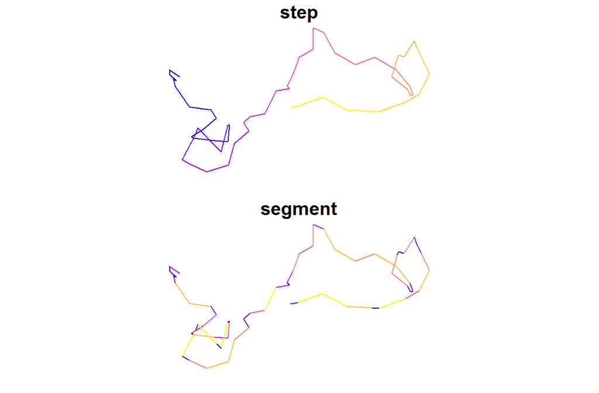

```r
plot(tr)
```

Возвращаясь к ранее загруженным данным:

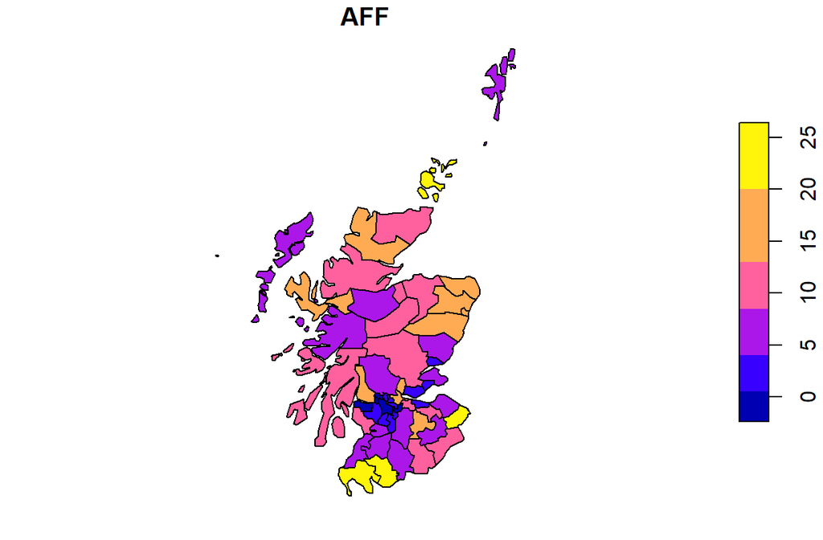

```r
plot(b.sf["AFF"])
```

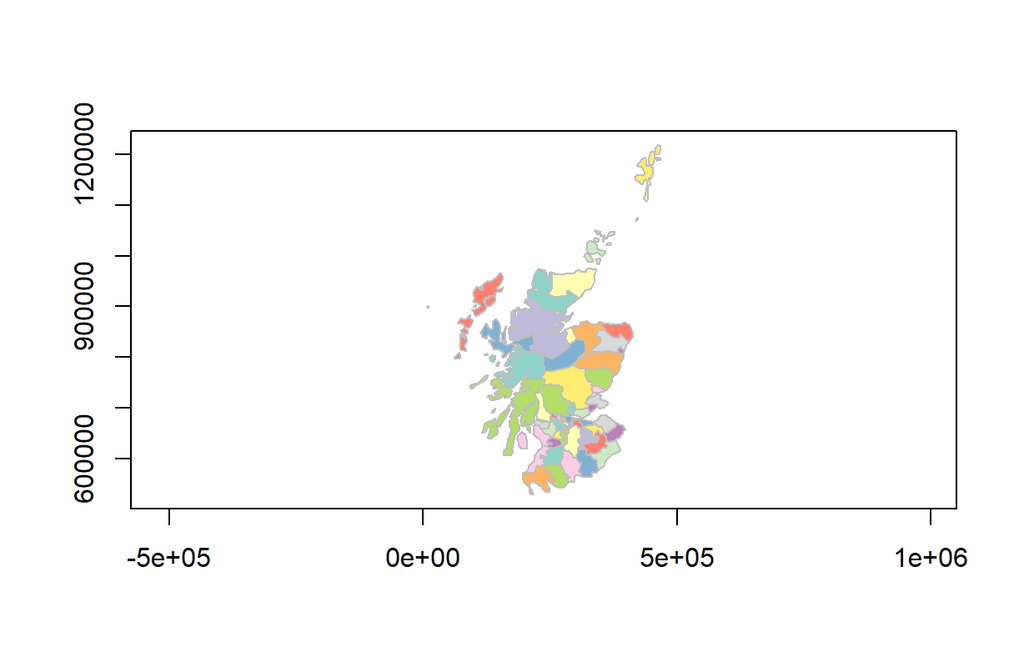

```r
plot(sf::st_geometry(b.sf),col=sf::sf.colors(12,categorical=TRUE)
    ,border='grey',axes=TRUE)
```

… Поэтому используются возможности других библиотек.

```r
require(ggplot2)
```

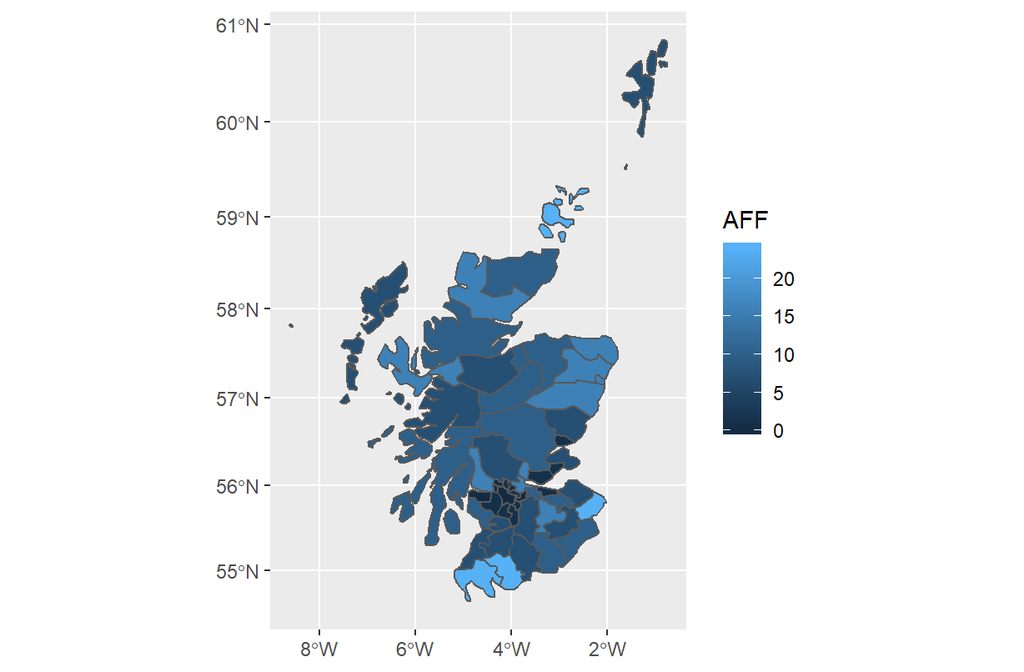

```r
ggplot()+geom_sf(data=b.sf,aes(fill=AFF))+coord_sf(crs=sf::st_crs(3857))
```

## Интерактивная визуализация

```r
mapview::mapview(b.sf) ## Не отобразится в Jupyter R Notebook.
```

[interactive chart not shown]

```r
require(leaflet)
```

```r
b <- sf::st_transform(b.sf,4326)
b$category <- factor(b$AFF,ordered=TRUE)
fpal <- colorFactor(topo.colors(5),b$category)
provList <- c("CartoDB.Positron","CartoDB.DarkMatter","Esri.OceanBasemap")
m <- leaflet()
for (p in c(provList)) m <- addProviderTiles(m,providers[[p]],group=p)
m <- m %>%
   addPolygons(data=b,fillColor=~fpal(category),fillOpacity=0.5
              ,weight=1.6,color=~fpal(category),opacity=0.75
              ,label=~paste0("AFF: ",AFF," (",NAME,")")
              ,popup=~sprintf("Например, поле COUNT, равное %.1f",COUNT)
              ) %>%
   addMeasure("topright",primaryLengthUnit="meters"
             ,primaryAreaUnit="sqmeters") %>%
   addScaleBar("bottomright"
             # ,options = scaleBarOptions(imperial=FALSE,maxWidth=400)
              ) %>%
   addLayersControl(position="topleft"
                   ,baseGroups=c(provList)
                   ,options=layersControlOptions(collapsed=TRUE)
                   ) %>%
   addLegend("bottomright",pal=fpal,values=b$category,opacity=0.6
            ,title="AFF")
```

```r
m ## Не отобразится в Jupyter R Notebook.
```

[interactive chart not shown]

## Экспорт пространственных данных

```r
pt <- loc
sp::coordinates(pt) <- ~x+y
sp::proj4string(pt) <- sp::proj4string(pt0)
pt <- sp::spTransform(pt,"+init=epsg:4326")
fileout1 <- "afterTrain.geojson"
rgdal::writeOGR(pt,fileout1,gsub("\\..+","",basename(fileout1)),driver="GeoJSON"
                 ,overwrite_layer=TRUE,morphToESRI=FALSE)
```

Проверим, появился ли файл:

```r
dir(pattern=paste0(gsub("\\..+","",basename(fileout1),".*")))
```

```
## [1] "afterTrain.geojson"
```

[figure not shown]

```r
try(ursa::glance(fileout1,style="mapnik",las=1,size=200,dpi=99))
```

```r
b.sf <- b.sf[,c("NAME","COUNT")]
b.sf$'категория' <- b$category
b.sf <- sf::st_transform(b.sf,3857)
fileout2 <- "scotland.sqlite"
sf::st_write(b.sf,dsn=fileout2,layer=gsub("\\..+","",basename(fileout2))
            ,driver="SQLite",layer_options=c("LAUNDER=NO"),quiet=TRUE
            ,delete_layer=file.exists(fileout2),delete_dsn=file.exists(fileout2))
```

```r
dir(pattern=paste0(gsub("\\..+","",basename(fileout2),".*")))
```

```
## [1] "scotland.sqlite"
```

```
## Note: unable to make bold caption for "категория"
```

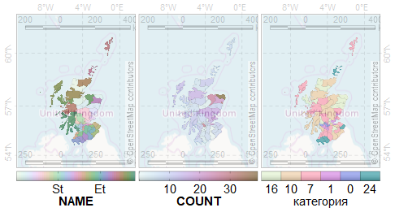

```r
try(ursa::glance(fileout2,style="mapnik",las=1,dpi=90,size=200))
```

```r
fileout3 <- "track.shp"
sf::st_write(tr,dsn=fileout3,layer=gsub("\\..+","",basename(fileout2))
            ,driver="ESRI Shapefile",quiet=TRUE
            ,delete_layer=file.exists(fileout3),delete_dsn=file.exists(fileout3))
```

```r
dir(pattern=paste0(gsub("\\..+","",basename(fileout3),".*")))
```

```
## [1] "track.dbf" "track.prj" "track.shp" "track.shx"
```

[figure not shown]

```r
try(ursa::glance(fileout3,style="mapnik",las=1,dpi=90,size=200))
```

## Рисование

Этот раздел предлагается пройти самостоятельно

```r
track <- sf::st_linestring(cbind(loc$x,loc$y))
track <- sf::st_sf(data.frame(desc="walk"
                  ,sf::st_sfc(track,crs=sp::proj4string(pt0))))
paint <- mapview::viewExtent(track,alpha=0.01) %>% mapedit::editMap("track")
result <- NULL
if (!is.null(paint$finished)) {
   result <- paint$finished
   mapview::mapview(result)
   ursa::session_grid(NULL)
   ursa::glance(result,style="mapnik")
}
```

## Воспроизводимые вычисления и публикация результата

Ниже приведены фрагмента кода, которые не были выполнены при составлении программы занятия. Их предлагается выполнить самостоятельно. Также необходимо установленный Pandoc.

Содержимое занятия сгенерировано из файла `main.R`. Загрузим его, переименовав:

```r
sfile <- "main.R"
rfile <- "lesson.R"
{
   if (file.exists(sfile))
      file.copy(sfile,rfile,overwrite=TRUE,copy.date=TRUE)
   else
      download.file(file.path("https://nplatonov.github.io/SCGIS2019",sfile)
                   ,rfile)
}
```

На основе этого файла создадим markdown-документ:

```r
mdfile <- knitr::spin(rfile,knit=FALSE)
mdfile
```

Затем из markdown-документа сформируем html-документ:

```r
if (rmarkdown::pandoc_available()) {
   htmlfile <- rmarkdown::render(mdfile,output_format="html_document"
                                ,output_options=list(toc=TRUE))
   print(basename(htmlfile))
}
```

Полученный html-документ можно открыть в браузере.

```r
if ((rmarkdown::pandoc_available())&&(file.exists(htmlfile)))
   browseURL(basename(htmlfile))
```

И можно скопировать на флешку на память:))

# Успехов!

## Дополнительная информация

### Как узнать об R поглубже

- [R-Bloggers](https://www.r-bloggers.com/) – современные тенденции R
- R’s [Spatial](https://cran.rstudio.com/web/views/Spatial.html) and [SpatioTemporal](https://cran.rstudio.com/web/views/SpatioTemporal.html) Task Views
- [R-Spatial](https://www.r-spatial.org/) – веб-сайт и блог для интересующихся использованием R для анализа пространственных и пространственно-временных данных
- [Stackoverflow](https://stackoverflow.com/feeds/tag/r) с тегом #R.
- [Stackexchange](https://gis.stackexchange.com/questions) о ГИС, в т.ч. с использованием R.
- Package’s vignettes – обобщенное знакомство с библиотекой. Обычно содержат воспроизводимый код.

### Ведущий

- Платонов Никита Геннадьевич ✉
- [ИПЭЭ РАН](http://www.sev-in.ru) – 85 лет в 2019 г. 🎂
- [Постоянно действующая экспедиция РАН по изучению животных Красной книги Российской Федерации и других особо важных животных фауны России](http://www.sevin-expedition.ru)
- [Программа изучения белого медведя в Российской Арктике](http://bear.sevin-expedition.ru)

Данные после занятия остались на диске. Если не нужны, выполнить следующее:

```r
file.remove(dir(pattern=paste0(gsub("\\..+","",basename(fileout1),".*"))))
file.remove(dir(pattern=paste0(gsub("\\..+","",basename(fileout2),".*"))))
file.remove(dir(pattern=paste0(gsub("\\..+","",basename(fileout3),".*"))))
```